# Medicare ACO Spending Patterns: Extension to 2014–2024

Eric Walczyk

October 03, 2026

## Overview

The replication (`ACO_Final.rmd`) covers 2014–2017. This file extends the same models through performance year 2024 using the MSSP Performance Year Financial and Quality Results PUFs, and tests whether the original findings survive the 2019 *Pathways to Success* redesign and the COVID-19 years.

### Load and Harmonize Data

```r
cap_vars <- c("capann_inp_all", "capann_opd", "capann_snf", "capann_pb",
              "capann_ambpay", "capann_hha", "capann_dme", "capann_hsp")

periods <- tribble(
  ~file,   ~period,         ~year,
  "2014",  "2014",          2014L,
  "2015",  "2015",          2015L,
  "2016",  "2016",          2016L,
  "2017",  "2017",          2017L,
  "2018",  "2018",          2018L,
  "2019",  "2019",          2019L,
  "2019A", "2019 Jul–Dec",  2019L,
  "2020",  "2020",          2020L,
  "2021",  "2021",          2021L,
  "2022",  "2022",          2022L,
  "2023",  "2023",          2023L,
  "2024",  "2024",          2024L
)

read_puf <- function(file) {
  df <- read_csv(file.path(data_dir, paste0(file, ".csv")),
                 col_types = cols(.default = "c"), show_col_types = FALSE) |>
    clean_names() |>
    rename_with(~ str_replace_all(.x, "^cap_ann_", "capann_")) |>
    rename_with(~ str_replace_all(.x, "amb_pay$", "ambpay"))

  # Sav_rate is a fraction (2014–2020), "5.50%" text (2019A, 2021–2023),
  # or a plain percent (2024): detect per file and convert to percentage points
  sav_raw <- df$sav_rate
  sav     <- parse_number(sav_raw, na = c("", "NA", "*"))
  is_pct  <- any(grepl("%", sav_raw)) || max(abs(sav), na.rm = TRUE) > 1

  tibble(
    file     = file,
    aco_num  = if ("aco_num" %in% names(df)) df$aco_num else NA_character_,
    aco_id   = if ("aco_id" %in% names(df)) df$aco_id else NA_character_,
    aco_name = df$aco_name,
    sav_rate = if (is_pct) sav else 100 * sav,
    # Agreement type and start date; 2014–2015 files have a single start date
    # (renewals began in 2016)
    agree_type      = if ("agree_type" %in% names(df)) df$agree_type else NA_character_,
    agreement_start = as.Date(lubridate::parse_date_time(
      if ("current_start_date" %in% names(df)) df$current_start_date else df$start_date,
      orders = c("mdy HM", "mdy", "ymd")))
  ) |>
    bind_cols(map_dfc(set_names(cap_vars), ~ parse_number(df[[.x]], na = c("", "NA", "*"))))
}

aco_raw <- map_dfr(periods$file, read_puf) |>
  left_join(periods, by = "file") |>
  mutate(period = factor(period, levels = periods$period))
```

```r
# Map 2014–2017 encrypted ACO_Num to the CMS ACO_ID with CMS's ACO ID crosswalk
# (https://www.cms.gov/files/document/ssp-aco-id-crosswalk.xlsx)
crosswalk <- readxl::read_excel(file.path(data_dir, "ssp-aco-id-crosswalk.xlsx"),
                                sheet = "ACO ID Crosswalk") |>
  clean_names() |>
  select(aco_num, xw_aco_id = aco_id)

aco_raw <- aco_raw |>
  left_join(crosswalk, by = "aco_num", na_matches = "never") |>
  mutate(id     = coalesce(aco_id, xw_aco_id),
         # Era-specific IDs, for the robustness check that does not link eras
         id_era = if_else(is.na(aco_num), paste0("ID:", aco_id), paste0("NUM:", aco_num)),
         # ACO x agreement period: CMS resets an ACO's benchmark when it starts a new agreement
         spell  = paste(id, agreement_start)) |>
  select(-xw_aco_id)

stopifnot(!anyNA(aco_raw$id), !anyNA(aco_raw$agreement_start))

n_old  <- n_distinct(aco_raw$aco_num, na.rm = TRUE)
n_both <- length(intersect(aco_raw$id[aco_raw$year <= 2017], aco_raw$id[aco_raw$year >= 2018]))
```

All 618 2014–2017 ACOs are in CMS’s crosswalk; 425 of them also appear in the 2018–2024 files.

```r
# Spending shares as a percent of the eight categories, plus the savings indicator
add_shares <- function(df) {
  df |>
    mutate(total_exp = rowSums(across(all_of(cap_vars)), na.rm = TRUE)) |>
    mutate(across(all_of(cap_vars), ~ 100 * .x / total_exp, .names = "{.col}_pct")) |>
    mutate(saved = as.integer(sav_rate > 0))
}

# Trim savings-rate outliers (1.5 x IQR) within each period
aco_data <- aco_raw |>
  group_by(period) |>
  filter(between(sav_rate,
                 quantile(sav_rate, 0.25, na.rm = TRUE) - 1.5 * IQR(sav_rate, na.rm = TRUE),
                 quantile(sav_rate, 0.75, na.rm = TRUE) + 1.5 * IQR(sav_rate, na.rm = TRUE))) |>
  ungroup() |>
  add_shares()

write_csv(aco_data, file.path(data_dir, "aco_panel_2014_2024.csv"))

aco_raw |>
  count(period, name = "ACOs (raw)") |>
  left_join(
    aco_data |>
      group_by(period) |>
      summarise(`ACOs (after trimming)` = n(),
                `Median savings rate (%)` = round(median(sav_rate), 2),
                `Share that saved (%)`    = round(100 * mean(saved), 1)),
    by = "period"
  ) |>
  rename(Period = period) |>
  knitr::kable(caption = "MSSP ACOs by performance period")
```

MSSP ACOs by performance period

| Period | ACOs (raw) | ACOs (after trimming) | Median savings rate (%) | Share that saved (%) |
| --- | --- | --- | --- | --- |
| 2014 | 333 | 315 | 0.32 | 54.0 |
| 2015 | 392 | 375 | 0.10 | 51.5 |
| 2016 | 432 | 417 | 0.57 | 56.1 |
| 2017 | 472 | 455 | 1.10 | 59.6 |
| 2018 | 548 | 523 | 1.43 | 67.1 |
| 2019 | 475 | 457 | 2.60 | 74.2 |
| 2019 Jul–Dec | 205 | 201 | 2.81 | 86.1 |
| 2020 | 513 | 496 | 3.83 | 84.3 |
| 2021 | 475 | 467 | 3.11 | 80.9 |
| 2022 | 482 | 473 | 3.41 | 84.1 |
| 2023 | 453 | 443 | 3.59 | 84.4 |
| 2024 | 476 | 460 | 4.10 | 88.7 |

## Spending Composition, 2014–2024

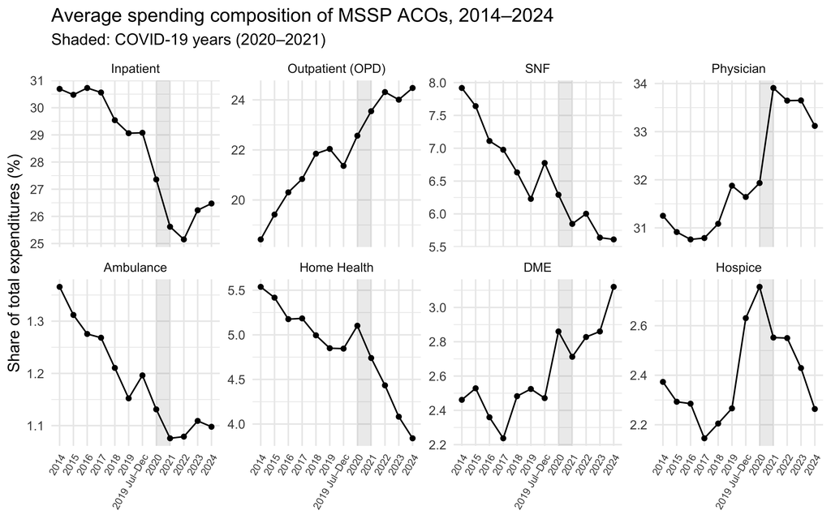

```r
share_labels <- c(
  capann_inp_all_pct = "Inpatient",
  capann_opd_pct     = "Outpatient (OPD)",
  capann_snf_pct     = "SNF",
  capann_pb_pct      = "Physician",
  capann_ambpay_pct  = "Ambulance",
  capann_hha_pct     = "Home Health",
  capann_dme_pct     = "DME",
  capann_hsp_pct     = "Hospice"
)

shares_by_period <- aco_data |>
  group_by(period) |>
  summarise(across(all_of(names(share_labels)), ~ mean(.x, na.rm = TRUE))) |>
  pivot_longer(-period, names_to = "category", values_to = "share") |>
  mutate(category = factor(share_labels[category], levels = share_labels))

p_shares <- ggplot(shares_by_period, aes(x = period, y = share, group = category)) +
  annotate("rect", xmin = "2020", xmax = "2021", ymin = -Inf, ymax = Inf, alpha = 0.12) +
  geom_line() +
  geom_point(size = 1.3) +
  facet_wrap(~ category, scales = "free_y", ncol = 4) +
  labs(title = "Average spending composition of MSSP ACOs, 2014–2024",
       subtitle = "Shaded: COVID-19 years (2020–2021)",
       x = NULL, y = "Share of total expenditures (%)") +
  theme_minimal(base_size = 11) +
  theme(axis.text.x = element_text(angle = 60, hjust = 1, size = 7))

ggsave(file.path(fig_dir, "spending_shares_2014_2024.png"), p_shares, width = 10, height = 5.5, dpi = 200, bg = "white")
p_shares
```

### Year Fixed-Effects on Spending Shares

The original study’s first model: each spending share regressed on year and ACO fixed effects, so each year coefficient is the average within-ACO change since 2014 (percentage points). Shares are used rather than per-capita dollars, which are nominal and would mostly reflect price growth over ten years.

```r
trend_data <- aco_data |> mutate(unit = id)

share_trends <- map(names(share_labels), ~ feols(
  as.formula(paste(.x, "~ i(period, ref = '2014') | unit")),
  data = trend_data, cluster = ~ unit, fixef.rm = "singleton"
)) |>
  set_names(share_labels)

trend_notes <- "Outcome is each category's share of total expenditures (%). Coefficients are changes relative to 2014 (pp). ACO fixed effects; SEs clustered by ACO."

modelsummary(share_trends, coef_rename = \(x) sub("^period::", "", x), stars = TRUE,
             estimate = "{estimate}{stars}", statistic = "({std.error})",
             gof_omit = "IC|Log|Adj|RMSE|Std.Errors",
             title = "Year Fixed-Effects on Spending Shares, 2014–2024",
             notes = trend_notes,
             output = file.path(out_dir, "extension_spending_trends.html"))

modelsummary(share_trends, coef_rename = \(x) sub("^period::", "", x), stars = TRUE,
             estimate = "{estimate}{stars}", statistic = "({std.error})",
             gof_omit = "IC|Log|Adj|RMSE|Std.Errors",
             title = "Year Fixed-Effects on Spending Shares, 2014–2024",
             notes = trend_notes,
             output = "html")
```

|  | Inpatient | Outpatient (OPD) | SNF | Physician | Ambulance | Home Health | DME | Hospice |
| --- | --- | --- | --- | --- | --- | --- | --- | --- |
| 2015 | −0.370*** | 0.304** | −0.227* | 0.342** | −0.065*** | −0.035 | 0.074*** | −0.023 |
|  | (0.075) | (0.097) | (0.090) | (0.126) | (0.019) | (0.064) | (0.019) | (0.033) |
| 2016 | 0.020 | 0.695*** | −0.851*** | 0.699*** | −0.135*** | −0.236* | −0.142*** | −0.051 |
|  | (0.108) | (0.121) | (0.147) | (0.189) | (0.022) | (0.094) | (0.025) | (0.050) |
| 2017 | −0.031 | 1.003*** | −0.797*** | 0.746*** | −0.148*** | −0.303** | −0.301*** | −0.169** |
|  | (0.117) | (0.136) | (0.160) | (0.210) | (0.022) | (0.116) | (0.035) | (0.060) |
| 2018 | −0.948*** | 1.904*** | −1.085*** | 1.028*** | −0.214*** | −0.513*** | −0.066* | −0.105+ |
|  | (0.121) | (0.151) | (0.170) | (0.226) | (0.023) | (0.117) | (0.031) | (0.064) |
| 2019 | −1.334*** | 2.323*** | −1.329*** | 1.371*** | −0.254*** | −0.731*** | −0.014 | −0.032 |
|  | (0.132) | (0.158) | (0.176) | (0.239) | (0.023) | (0.121) | (0.032) | (0.064) |
| 2019 Jul–Dec | −1.318*** | 2.012*** | −1.309*** | 1.313*** | −0.235*** | −0.679*** | −0.007 | 0.222* |
|  | (0.148) | (0.186) | (0.199) | (0.274) | (0.025) | (0.122) | (0.035) | (0.087) |
| 2020 | −3.041*** | 2.933*** | −1.468*** | 1.708*** | −0.292*** | −0.520*** | 0.337*** | 0.343*** |
|  | (0.154) | (0.174) | (0.191) | (0.268) | (0.024) | (0.128) | (0.034) | (0.075) |
| 2021 | −4.802*** | 3.869*** | −1.982*** | 3.829*** | −0.362*** | −0.887*** | 0.197*** | 0.137+ |
|  | (0.157) | (0.185) | (0.193) | (0.275) | (0.024) | (0.130) | (0.036) | (0.075) |
| 2022 | −5.200*** | 4.388*** | −1.754*** | 3.595*** | −0.384*** | −1.112*** | 0.314*** | 0.153* |
|  | (0.158) | (0.192) | (0.204) | (0.284) | (0.025) | (0.132) | (0.036) | (0.076) |
| 2023 | −4.137*** | 3.843*** | −2.150*** | 3.772*** | −0.341*** | −1.360*** | 0.345*** | 0.027 |
|  | (0.162) | (0.202) | (0.203) | (0.295) | (0.026) | (0.129) | (0.036) | (0.077) |
| 2024 | −4.019*** | 4.228*** | −2.210*** | 3.475*** | −0.375*** | −1.590*** | 0.597*** | −0.106 |
|  | (0.169) | (0.216) | (0.207) | (0.309) | (0.027) | (0.132) | (0.038) | (0.081) |
| Num.Obs. | 4936 | 4936 | 4936 | 4936 | 4936 | 4936 | 4936 | 4936 |
| R2 | 0.890 | 0.952 | 0.820 | 0.938 | 0.881 | 0.897 | 0.864 | 0.800 |
| R2 Within | 0.662 | 0.379 | 0.143 | 0.259 | 0.228 | 0.235 | 0.404 | 0.052 |
| FE: unit | X | X | X | X | X | X | X | X |

Outcome is each category's share of total expenditures (%). Coefficients are changes relative to 2014 (pp). ACO fixed effects; SEs clustered by ACO.

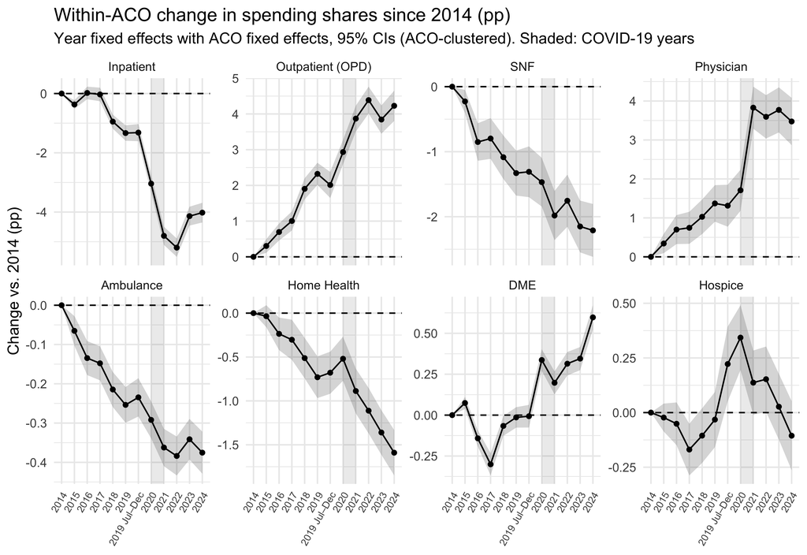

```r
trend_coefs <- imap_dfr(share_trends, function(m, category) {
  ct <- coeftable(m)
  ci <- confint(m)
  tibble(category = category, period = sub("^period::", "", rownames(ct)),
         estimate = ct[, "Estimate"], low = ci[, 1], high = ci[, 2])
}) |>
  bind_rows(tibble(category = names(share_trends), period = "2014", estimate = 0, low = 0, high = 0)) |>
  mutate(period   = factor(period, levels = levels(aco_data$period)),
         category = factor(category, levels = share_labels))

p_trends <- ggplot(trend_coefs, aes(x = period, y = estimate, group = category)) +
  annotate("rect", xmin = "2020", xmax = "2021", ymin = -Inf, ymax = Inf, alpha = 0.12) +
  geom_hline(yintercept = 0, linetype = "dashed") +
  geom_ribbon(aes(ymin = low, ymax = high), alpha = 0.2) +
  geom_line() +
  geom_point(size = 1.3) +
  facet_wrap(~ category, scales = "free_y", ncol = 4) +
  labs(title = "Within-ACO change in spending shares since 2014 (pp)",
       subtitle = "Year fixed effects with ACO fixed effects, 95% CIs (ACO-clustered). Shaded: COVID-19 years",
       x = NULL, y = "Change vs. 2014 (pp)") +
  theme_minimal(base_size = 11) +
  theme(axis.text.x = element_text(angle = 60, hjust = 1, size = 7))

ggsave(file.path(fig_dir, "spending_trends_2014_2024.png"), p_trends, width = 10, height = 5.5, dpi = 200, bg = "white")
p_trends
```

## Savings Models, 2014–2024

```r
# Same specifications as the replication; OPD share is the omitted category
fml_full    <- c("capann_inp_all_pct", "capann_hsp_pct", "capann_snf_pct", "capann_pb_pct",
                 "capann_ambpay_pct", "capann_hha_pct", "capann_dme_pct")
fml_reduced <- c("capann_inp_all_pct", "capann_hsp_pct", "capann_snf_pct", "capann_pb_pct", "capann_hha_pct")

# `unit` and period fixed effects; `unit` is the ACO unless a robustness check
# says otherwise. SEs are always clustered by ACO (`id`).
twfe <- function(outcome, rhs) as.formula(paste(outcome, "~", paste(rhs, collapse = " + "), "| unit + period"))

# Units seen in only one period add no within-unit variation, so they are dropped
fit_fe    <- function(rhs, data) feols(twfe("sav_rate", rhs), data = data, cluster = ~ id, fixef.rm = "singleton")
fit_logit <- function(rhs, data) feglm(twfe("saved", rhs), data = data, family = binomial(), cluster = ~ id)

coef_labels <- c(
  capann_inp_all_pct = "Percent Inpatient",
  capann_hsp_pct     = "Percent Hospice",
  capann_snf_pct     = "Percent SNF",
  capann_pb_pct      = "Percent Physician",
  capann_ambpay_pct  = "Percent Ambulance",
  capann_hha_pct     = "Percent Home Health",
  capann_dme_pct     = "Percent DME"
)

full_sample <- aco_data |> mutate(unit = id)

main_models <- list(
  "FE: Savings Rate (Full)"    = fit_fe(fml_full, full_sample),
  "FE: Savings Rate (Reduced)" = fit_fe(fml_reduced, full_sample),
  "Logit: Full"                = fit_logit(fml_full, full_sample),
  "Logit: Reduced"             = fit_logit(fml_reduced, full_sample)
)

main_notes <- "ACO and performance-period fixed effects; SEs clustered by ACO. FE outcome is the savings rate (percentage points). Logit outcome is 1 if the ACO generated savings; coefficients are log-odds. Outpatient (OPD) share is the omitted category. The FE logit drops ACOs whose outcome never varies."

modelsummary(main_models, coef_map = coef_labels, stars = TRUE,
             estimate = "{estimate}{stars}", statistic = "({std.error})",
             gof_omit = "IC|Log|Adj|RMSE|Std.Errors",
             title = "Spending Composition and ACO Savings, 2014–2024",
             notes = main_notes,
             output = file.path(out_dir, "extension_main_results.html"))

modelsummary(main_models, coef_map = coef_labels, stars = TRUE,
             estimate = "{estimate}{stars}", statistic = "({std.error})",
             gof_omit = "IC|Log|Adj|RMSE|Std.Errors",
             title = "Spending Composition and ACO Savings, 2014–2024",
             notes = main_notes,
             output = "html")
```

|  | FE: Savings Rate (Full) | FE: Savings Rate (Reduced) | Logit: Full | Logit: Reduced |
| --- | --- | --- | --- | --- |
| Percent Inpatient | −0.365*** | −0.381*** | −0.286*** | −0.305*** |
|  | (0.065) | (0.064) | (0.083) | (0.081) |
| Percent Hospice | −0.343*** | −0.352*** | −0.215+ | −0.223+ |
|  | (0.101) | (0.102) | (0.122) | (0.123) |
| Percent SNF | −0.205** | −0.220*** | −0.142* | −0.173* |
|  | (0.067) | (0.066) | (0.071) | (0.069) |
| Percent Physician | 0.095+ | 0.071 | 0.119* | 0.104+ |
|  | (0.051) | (0.049) | (0.060) | (0.058) |
| Percent Ambulance | 0.597 |  | 0.425 |  |
|  | (0.409) |  | (0.433) |  |
| Percent Home Health | 0.010 | −0.019 | −0.083 | −0.115 |
|  | (0.101) | (0.102) | (0.116) | (0.112) |
| Percent DME | 0.268 |  | 0.660* |  |
|  | (0.232) |  | (0.282) |  |
| Num.Obs. | 4936 | 4936 | 3127 | 3127 |
| R2 | 0.599 | 0.598 | 0.261 | 0.258 |
| R2 Within | 0.057 | 0.056 | 0.048 | 0.044 |
| FE: unit | X | X | X | X |
| FE: period | X | X | X | X |

ACO and performance-period fixed effects; SEs clustered by ACO. FE outcome is the savings rate (percentage points). Logit outcome is 1 if the ACO generated savings; coefficients are log-odds. Outpatient (OPD) share is the omitted category. The FE logit drops ACOs whose outcome never varies.

## Robustness

Each column re-estimates the full specification on a different sample:

- **2014–2017**: the replication window, now with two-way fixed effects
- **2014–2024**: all periods (main estimate)
- **Excl. 2020–21**: drops the COVID-19 years
- **2014–2018 / 2019–2024**: before and after the 2019 *Pathways to Success* redesign
- **Unlinked ID eras**: all periods, treating 2014–2017 and 2018+ ACO IDs as separate units
- **Within agreement**: all periods, comparing each ACO only within the same agreement period (ACO × agreement fixed effects). CMS resets an ACO’s benchmark when it starts a new agreement, which changes its savings rate without any change in spending; by 2022, most ACOs were in renewed or re-entered agreements.

```r
samples <- list(
  "2014–2017"         = aco_data |> filter(year <= 2017)         |> mutate(unit = id),
  "2014–2024"         = aco_data                                 |> mutate(unit = id),
  "Excl. 2020–21"     = aco_data |> filter(!year %in% 2020:2021) |> mutate(unit = id),
  "2014–2018"         = aco_data |> filter(year <= 2018)         |> mutate(unit = id),
  "2019–2024"         = aco_data |> filter(year >= 2019)         |> mutate(unit = id),
  "Unlinked ID eras"  = aco_data                                 |> mutate(unit = id_era),
  "Within agreement"  = aco_data                                 |> mutate(unit = spell)
)

robust_fe    <- map(samples, ~ fit_fe(fml_full, .x))
robust_logit <- map(samples, ~ fit_logit(fml_full, .x))

modelsummary(robust_fe, coef_map = coef_labels, stars = TRUE,
             estimate = "{estimate}{stars}", statistic = "({std.error})",
             gof_omit = "IC|Log|Adj|RMSE|Std.Errors",
             title = "Robustness: Fixed-Effects Regression on Savings Rate (Full Specification)",
             notes = "ACO and performance-period fixed effects; SEs clustered by ACO.",
             output = "html")
```

|  | 2014–2017 | 2014–2024 | Excl. 2020–21 | 2014–2018 | 2019–2024 | Unlinked ID eras | Within agreement |
| --- | --- | --- | --- | --- | --- | --- | --- |
| Percent Inpatient | −0.499** | −0.365*** | −0.434*** | −0.495*** | −0.215* | −0.292*** | −0.314*** |
|  | (0.168) | (0.065) | (0.071) | (0.125) | (0.084) | (0.073) | (0.075) |
| Percent Hospice | −0.173 | −0.343*** | −0.401*** | −0.180 | −0.349* | −0.254* | −0.204+ |
|  | (0.235) | (0.101) | (0.114) | (0.187) | (0.161) | (0.110) | (0.119) |
| Percent SNF | −0.292* | −0.205** | −0.183** | −0.240* | −0.378** | −0.301*** | −0.277*** |
|  | (0.132) | (0.067) | (0.068) | (0.111) | (0.119) | (0.074) | (0.077) |
| Percent Physician | 0.048 | 0.095+ | 0.081 | 0.042 | 0.160** | 0.107* | 0.128* |
|  | (0.128) | (0.051) | (0.055) | (0.106) | (0.060) | (0.050) | (0.050) |
| Percent Ambulance | −0.247 | 0.597 | 0.596 | −0.159 | 0.955 | 0.340 | 0.364 |
|  | (0.506) | (0.409) | (0.423) | (0.477) | (0.676) | (0.399) | (0.408) |
| Percent Home Health | −0.284+ | 0.010 | −0.021 | −0.201 | 0.023 | −0.070 | −0.206 |
|  | (0.172) | (0.101) | (0.112) | (0.141) | (0.169) | (0.114) | (0.126) |
| Percent DME | 0.198 | 0.268 | 0.140 | 0.211 | 0.780* | 0.497* | 0.789** |
|  | (0.392) | (0.232) | (0.243) | (0.353) | (0.323) | (0.236) | (0.301) |
| Num.Obs. | 1422 | 4936 | 3957 | 1911 | 2835 | 4782 | 4779 |
| R2 | 0.667 | 0.599 | 0.622 | 0.647 | 0.662 | 0.679 | 0.781 |
| R2 Within | 0.067 | 0.057 | 0.064 | 0.060 | 0.076 | 0.062 | 0.075 |
| FE: unit | X | X | X | X | X | X | X |
| FE: period | X | X | X | X | X | X | X |

ACO and performance-period fixed effects; SEs clustered by ACO.

```r
modelsummary(robust_logit, coef_map = coef_labels, stars = TRUE,
             estimate = "{estimate}{stars}", statistic = "({std.error})",
             gof_omit = "IC|Log|Adj|RMSE|Std.Errors",
             title = "Robustness: Fixed-Effects Logit on Achieving Savings (Full Specification)",
             notes = "ACO and performance-period fixed effects; SEs clustered by ACO. Coefficients are log-odds.",
             output = "html")
```

|  | 2014–2017 | 2014–2024 | Excl. 2020–21 | 2014–2018 | 2019–2024 | Unlinked ID eras | Within agreement |
| --- | --- | --- | --- | --- | --- | --- | --- |
| Percent Inpatient | −0.549* | −0.286*** | −0.396*** | −0.507** | −0.380** | −0.407*** | −0.574*** |
|  | (0.234) | (0.083) | (0.087) | (0.174) | (0.125) | (0.098) | (0.126) |
| Percent Hospice | −0.269 | −0.215+ | −0.200 | 0.070 | −0.371* | −0.219 | −0.245 |
|  | (0.395) | (0.122) | (0.148) | (0.283) | (0.186) | (0.150) | (0.221) |
| Percent SNF | −0.173 | −0.142* | −0.176* | −0.171 | −0.254* | −0.255** | −0.202 |
|  | (0.173) | (0.071) | (0.082) | (0.153) | (0.123) | (0.088) | (0.129) |
| Percent Physician | 0.227 | 0.119* | 0.077 | 0.173 | 0.138 | 0.139+ | 0.230* |
|  | (0.204) | (0.060) | (0.072) | (0.154) | (0.090) | (0.073) | (0.112) |
| Percent Ambulance | −0.560 | 0.425 | 0.423 | 0.188 | 0.832 | 0.304 | 1.196 |
|  | (0.826) | (0.433) | (0.484) | (0.699) | (1.060) | (0.634) | (0.844) |
| Percent Home Health | −0.325 | −0.083 | −0.127 | −0.315 | −0.010 | −0.141 | −0.296 |
|  | (0.212) | (0.116) | (0.124) | (0.211) | (0.280) | (0.139) | (0.211) |
| Percent DME | 0.474 | 0.660* | 0.721* | 0.908+ | 0.682 | 0.704* | 0.804 |
|  | (0.651) | (0.282) | (0.326) | (0.531) | (0.469) | (0.336) | (0.522) |
| Num.Obs. | 761 | 3127 | 2411 | 1085 | 1097 | 2285 | 1697 |
| R2 | 0.191 | 0.261 | 0.256 | 0.213 | 0.193 | 0.222 | 0.203 |
| R2 Within | 0.082 | 0.048 | 0.056 | 0.067 | 0.056 | 0.062 | 0.072 |
| FE: unit | X | X | X | X | X | X | X |
| FE: period | X | X | X | X | X | X | X |

ACO and performance-period fixed effects; SEs clustered by ACO. Coefficients are log-odds.

```r
modelsummary(c(setNames(robust_fe, paste("FE:", names(robust_fe))),
               setNames(robust_logit, paste("Logit:", names(robust_logit)))),
             coef_map = coef_labels, stars = TRUE,
             estimate = "{estimate}{stars}", statistic = "({std.error})",
             gof_omit = "IC|Log|Adj|RMSE|Std.Errors",
             title = "Robustness: FE Savings-Rate and FE Logit Models Across Samples",
             notes = "ACO and performance-period fixed effects; SEs clustered by ACO.",
             output = file.path(out_dir, "extension_robustness.html"))
```

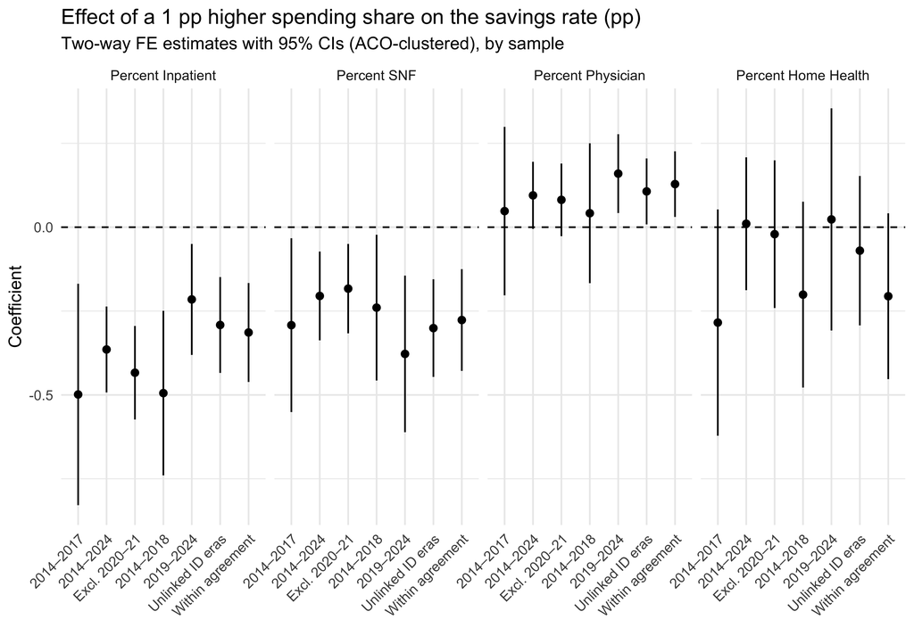

```r
key_terms <- c("capann_inp_all_pct", "capann_snf_pct", "capann_pb_pct", "capann_hha_pct")

stability <- imap_dfr(robust_fe, function(m, sample) {
  ct <- coeftable(m)
  ci <- confint(m)
  tibble(sample = sample, term = rownames(ct), estimate = ct[, "Estimate"],
         low = ci[, 1], high = ci[, 2])
}) |>
  filter(term %in% key_terms) |>
  mutate(term   = factor(coef_labels[term], levels = coef_labels[key_terms]),
         sample = factor(sample, levels = names(samples)))

p_stability <- ggplot(stability, aes(x = sample, y = estimate)) +
  geom_hline(yintercept = 0, linetype = "dashed") +
  geom_pointrange(aes(ymin = low, ymax = high), size = 0.3) +
  facet_wrap(~ term, ncol = 4) +
  labs(title = "Effect of a 1 pp higher spending share on the savings rate (pp)",
       subtitle = "Two-way FE estimates with 95% CIs (ACO-clustered), by sample",
       x = NULL, y = "Coefficient") +
  theme_minimal(base_size = 11) +
  theme(axis.text.x = element_text(angle = 45, hjust = 1))

ggsave(file.path(fig_dir, "coefficient_stability.png"), p_stability, width = 10, height = 5, dpi = 200, bg = "white")
p_stability
```

## Model Fit

The within R² of the savings-rate models is low. This table shows how it changes with three choices: counting the period dummies in R² (as Stata’s `xtreg` does, and as the original study appears to), keeping savings-rate outliers, and comparing each ACO only within the same agreement period. Savings rates rose about tenfold over 2014–2024, so the period effects absorb much of the within-ACO change in savings.

```r
aco_all <- add_shares(aco_raw)

fit_row <- function(data, label) {
  m  <- fit_fe(fml_full, data)
  md <- feols(as.formula(paste("sav_rate ~", paste(fml_full, collapse = " + "), "+ i(period) | unit")),
              data = data, cluster = ~ id, fixef.rm = "singleton")
  tibble(Sample = label, `ACO-years` = nobs(m),
         `Within R² (models above)` = round(r2(m, "wr2"), 3),
         `Within R² counting period dummies` = round(r2(md, "wr2"), 3))
}

bind_rows(
  fit_row(aco_data |> mutate(unit = id), "Outliers dropped (main)"),
  fit_row(aco_all |> mutate(unit = id), "All ACO-years"),
  fit_row(aco_all |> filter(is.na(agree_type) | agree_type == "Initial") |> mutate(unit = id),
          "All ACO-years, first agreements only"),
  fit_row(aco_data |> mutate(unit = spell), "Outliers dropped, within agreement")
) |>
  knitr::kable(caption = "Within R² of the full savings-rate model, 2014–2024")
```

Within R² of the full savings-rate model, 2014–2024

| Sample | ACO-years | Within R² (models above) | Within R² counting period dummies |
| --- | --- | --- | --- |
| Outliers dropped (main) | 4936 | 0.057 | 0.190 |
| All ACO-years | 5117 | 0.082 | 0.184 |
| All ACO-years, first agreements only | 2406 | 0.133 | 0.178 |
| Outliers dropped, within agreement | 4779 | 0.075 | 0.141 |